# The Fourier Transform

How a machine finds which notes are hidden in a chord.

15 May 2026

An instrument plays three notes at once, but you hear a single chord. Physically, all three notes create pressure waves that sum together and hit your eardrum as one. Your brain is somehow able to recognize the three distinct frequencies hidden in that single wave. The mechanism behind how the brain does this is an extremely complicated topic, but getting machines to decompose the signal is quite straightforward. The mathematical operation that does this decomposition is called the **Fourier Transform**.

## Sound is a sum of sinusoids

A **pure tone** (a tuning fork or a whistle) is a sinusoid. A sinusoid is a smooth, repetitive oscillation at a single frequency. If you stack multiple pure tones on top of each other, you get a **chord**. The sounds you hear in your ear on a daily basis are typically a sum of hundreds of pure tones. When looking at the waveforms of chords, it looks like pure noise (see Figure 1), but it isn’t noise. The pure tones are just hiding in the sum of frequencies of the chord signal.

Below you can hear three different pure tones and the chord they produce when combined. Then below the media players, you can see the wave forms of the signals individually and then the signal that is produced when combining the three pure tones.

```python
fs = 8000
t = np.linspace(0, 1.5, int(fs * 1.5), endpoint=False)
note_freqs = [300, 700, 1200]  # Hz ratio 3:7:12, matching the figure below
note_amps = [1.0, 0.7, 0.4]
chord = sum(a * np.cos(2 * np.pi * f * t) for f, a in zip(note_freqs, note_amps))
```

Note 1 (low)

[interactive chart not shown]

Note 2 (mid)

[interactive chart not shown]

Note 3 (high)

[interactive chart not shown]

The chord

[interactive chart not shown]

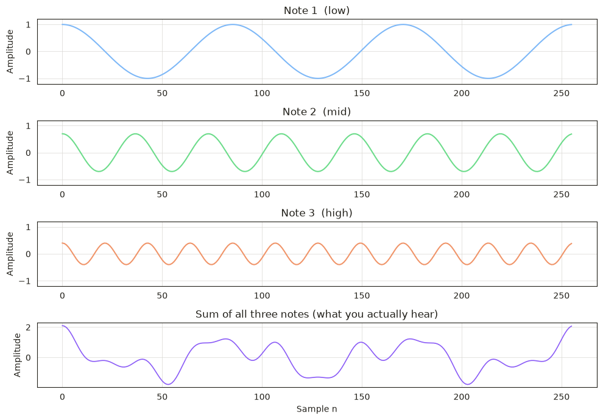

[figure not shown]

Figure 1: Three pure tones (top three panels) add up to one complicated waveform (bottom). The individual notes are nowhere to be seen in the mixture.

## How to detect a hidden frequency

The intuition behind finding the frequencies in a chord is that if the frequency $f$ is present in the signal, then the signal and a pure tone at $f$ should “agree” on average. “Agreeing” in this context means that when the test pure tone is positive, the signal tends to be positive, and when the test tone is negative, the signal also tends to be negative.

The mathematical way to measure this agreement is the **dot product**. In practice, you multiply the signal and the test sinusoid at each discrete time point and then sum all the multiplications together (aka you take the dot product). If the products are consistently positive (or consistently negative) the sum is large and this means that the test frequency can be found from the original signal. If the test frequency doesn’t match with the original signal, the products alternate in sign and cancel out and the sum collapses to zero. This is the entire intuition of the Fourier transform. The Fourier transform just tests every frequency and then returns a list of frequencies present.

## The formula

For a discrete signal $x[0], x[1], \ldots, x[N-1]$, the $k$-th Fourier coefficient is:

$$X[k] = \sum_{n=0}^{N-1} x[n]\, e^{-2\pi \mathrm{i} k n / N}$$
(1)

where $e^{-2\pi \mathrm{i} k n / N}$ is a complex sinusoid at frequency $k$. This comes from Euler’s formula: $e^{\mathrm{i}\theta} = \cos \theta + \mathrm{i}\sin \theta$. Multiplying $x[n]$ by $e^{-2\pi \mathrm{i} k n / N}$ and summing is, by definition, the dot product of the signal and the test sinusoid at frequency $k$.

The result $X[k]$ is a complex number. Its magnitude $|X[k]|$ tells you how much of frequency $k$ is present. It is complex because $e^{-2\pi \mathrm{i} kn/N} = \cos(2\pi kn/N) - \mathrm{i}\sin(2\pi kn/N)$, so the real part measures correlation with the cosine and the imaginary part with the sine. Together they capture both the **amplitude** and **phase** of each frequency in a single number. Repeating for all $k = 0, 1, \ldots, N-1$ gives the full spectrum of which frequencies are in the signal and how strong each one is.

## Geometric intuition: winding a signal around a circle

There is a nice geometric way to understand what Equation 1 is doing. The idea is that you take the signal and wind it around a circle. At sample $n$, place the value $x[n]$ on the complex plane, rotated by $k$ full turns spread over $N$ samples. Then each point becomes a point in 2D space. The sum $X[k]$, divided by $N$, is the **centre of mass** of all these points.